# Final report _ Group - Akansha,Abhishek,Rajashree

## Exploratory Data Analyis and Data Cleaning

### Step 1 : Train Data Import & EDA

### Step 2 : Removed the columns which are having most of NA’s

### Step 3 : Test Data Import and perfoming EDA as performed on Train

### Step 4 : Imputed rest of the columns of Train and Test dataset using MissForest

```r
library(arm)
library(caret)
library(dplyr)
library(missForest)
library(randomForest)
library(MASS)
# Import train Data
train_data <- read.csv(file.choose(),stringsAsFactors = FALSE)
# Most of NA' found in below variables :
# Alley, Fence , MiscFeature
# So removing those 4 Alley,Fence,Miscfeature,PoolQC columns Fence,MiscFeature,Alley
train_data <- train_data[-7]
train_data <-  subset(train_data, select=-c(Fence,MiscFeature,PoolQC))
#Importing Test Data
test_data <- read.csv(file.choose(),stringsAsFactors = FALSE)
# Most of NA' found in below variables :
# Alley, Fence , MiscFeature
# So removing those 4 Alley,Fence,Miscfeature,PoolQC columns Fence,MiscFeature,Alley
test_data <- test_data[-7]
test_data <-  subset(test_data, select=-c(Fence,MiscFeature,PoolQC))
#Cleaning Function for Train Data Set
elements <- names(train_data)
elements <- elements[elements != "SalePrice"]
for(i in elements)
{
  if(any(is.na(train_data[[i]])))
  {
    if(is.character(train_data[[i]]))
    {
      train_data[[i]][is.na(train_data[[i]])] <- "zero"
      }
  }
}
for(i in elements)
{
  if(is.character(train_data[[i]]))
  {
    levels <- sort(unique(c(train_data[[i]])))
    train_data[[i]] <- factor(train_data[[i]],levels=levels)
  }
}
for (i in elements) {
  if(class(levels(train_data[[i]])) == "character")
    train_data[[i]] <- seq_along(levels(train_data[[i]]))[train_data[[i]]]
}
#Imputation Using MissForest
set.seed(1234)
newtrain_data<-missForest(train_data)
```

```
  missForest iteration 1 in progress...done!
  missForest iteration 2 in progress...done!
  missForest iteration 3 in progress...done!
  missForest iteration 4 in progress...done!
  missForest iteration 5 in progress...done!
```

```r
summary(newtrain_data$ximp)
```

```
       Id           MSSubClass       MSZoning      LotFrontage        LotArea
 Min.   :   1.0   Min.   : 20.0   Min.   :1.000   Min.   : 21.00   Min.   :  1300
 1st Qu.: 365.8   1st Qu.: 20.0   1st Qu.:4.000   1st Qu.: 60.00   1st Qu.:  7554
 Median : 730.5   Median : 50.0   Median :4.000   Median : 70.00   Median :  9478
 Mean   : 730.5   Mean   : 56.9   Mean   :4.029   Mean   : 70.78   Mean   : 10517
 3rd Qu.:1095.2   3rd Qu.: 70.0   3rd Qu.:4.000   3rd Qu.: 81.00   3rd Qu.: 11602
 Max.   :1460.0   Max.   :190.0   Max.   :5.000   Max.   :313.00   Max.   :215245
     Street         LotShape      LandContour      Utilities       LotConfig
 Min.   :1.000   Min.   :1.000   Min.   :1.000   Min.   :1.000   Min.   :1.000
 1st Qu.:2.000   1st Qu.:1.000   1st Qu.:4.000   1st Qu.:1.000   1st Qu.:3.000
 Median :2.000   Median :4.000   Median :4.000   Median :1.000   Median :5.000
 Mean   :1.996   Mean   :2.942   Mean   :3.777   Mean   :1.001   Mean   :4.019
 3rd Qu.:2.000   3rd Qu.:4.000   3rd Qu.:4.000   3rd Qu.:1.000   3rd Qu.:5.000
 Max.   :2.000   Max.   :4.000   Max.   :4.000   Max.   :2.000   Max.   :5.000
   LandSlope      Neighborhood     Condition1      Condition2       BldgType
 Min.   :1.000   Min.   : 1.00   Min.   :1.000   Min.   :1.000   Min.   :1.000
 1st Qu.:1.000   1st Qu.: 8.00   1st Qu.:3.000   1st Qu.:3.000   1st Qu.:1.000
 Median :1.000   Median :13.00   Median :3.000   Median :3.000   Median :1.000
 Mean   :1.062   Mean   :13.15   Mean   :3.032   Mean   :3.008   Mean   :1.493
 3rd Qu.:1.000   3rd Qu.:18.00   3rd Qu.:3.000   3rd Qu.:3.000   3rd Qu.:1.000
 Max.   :3.000   Max.   :25.00   Max.   :9.000   Max.   :8.000   Max.   :5.000
   HouseStyle     OverallQual      OverallCond      YearBuilt     YearRemodAdd
 Min.   :1.000   Min.   : 1.000   Min.   :1.000   Min.   :1872   Min.   :1950
 1st Qu.:3.000   1st Qu.: 5.000   1st Qu.:5.000   1st Qu.:1954   1st Qu.:1967
 Median :3.000   Median : 6.000   Median :5.000   Median :1973   Median :1994
 Mean   :4.038   Mean   : 6.099   Mean   :5.575   Mean   :1971   Mean   :1985
 3rd Qu.:6.000   3rd Qu.: 7.000   3rd Qu.:6.000   3rd Qu.:2000   3rd Qu.:2004
 Max.   :8.000   Max.   :10.000   Max.   :9.000   Max.   :2010   Max.   :2010
   RoofStyle       RoofMatl      Exterior1st     Exterior2nd      MasVnrType
 Min.   :1.00   Min.   :1.000   Min.   : 1.00   Min.   : 1.00   Min.   :1.000
 1st Qu.:2.00   1st Qu.:2.000   1st Qu.: 9.00   1st Qu.: 9.00   1st Qu.:2.000
 Median :2.00   Median :2.000   Median :13.00   Median :14.00   Median :3.000
 Mean   :2.41   Mean   :2.075   Mean   :10.62   Mean   :11.34   Mean   :2.773
 3rd Qu.:2.00   3rd Qu.:2.000   3rd Qu.:13.00   3rd Qu.:14.00   3rd Qu.:3.000
 Max.   :6.00   Max.   :8.000   Max.   :15.00   Max.   :16.00   Max.   :5.000
   MasVnrArea       ExterQual      ExterCond       Foundation       BsmtQual
 Min.   :   0.0   Min.   :1.00   Min.   :1.000   Min.   :1.000   Min.   :1.000
 1st Qu.:   0.0   1st Qu.:3.00   1st Qu.:5.000   1st Qu.:2.000   1st Qu.:3.000
 Median :   0.0   Median :4.00   Median :5.000   Median :2.000   Median :3.000
 Mean   : 103.9   Mean   :3.54   Mean   :4.734   Mean   :2.397   Mean   :3.305
```

[output cut: 57 more lines]

```
 Max.   :857.00   Max.   :547.00   Max.   :552.00   Max.   :508.00   Max.   :480.00
    PoolArea          MiscVal             MoSold           YrSold        SaleType
 Min.   :  0.000   Min.   :    0.00   Min.   : 1.000   Min.   :2006   Min.   :1.00
 1st Qu.:  0.000   1st Qu.:    0.00   1st Qu.: 5.000   1st Qu.:2007   1st Qu.:9.00
 Median :  0.000   Median :    0.00   Median : 6.000   Median :2008   Median :9.00
 Mean   :  2.759   Mean   :   43.49   Mean   : 6.322   Mean   :2008   Mean   :8.51
 3rd Qu.:  0.000   3rd Qu.:    0.00   3rd Qu.: 8.000   3rd Qu.:2009   3rd Qu.:9.00
 Max.   :738.000   Max.   :15500.00   Max.   :12.000   Max.   :2010   Max.   :9.00
 SaleCondition     SalePrice
 Min.   :1.000   Min.   : 34900
 1st Qu.:5.000   1st Qu.:129975
 Median :5.000   Median :163000
 Mean   :4.771   Mean   :180921
 3rd Qu.:5.000   3rd Qu.:214000
 Max.   :6.000   Max.   :755000
```

```r
train_data<-newtrain_data$ximp
#Cleaning Function for Test Data
elements <- names(test_data)
elements <- elements[elements != "SalePrice"]
for(i in elements)
{
  if(any(is.na(test_data[[i]])))
  {
    if(is.character(test_data[[i]]))
    {
      test_data[[i]][is.na(test_data[[i]])] <- "zero"
      }
  }
}
for(i in elements)
{
  if(is.character(test_data[[i]]))
  {
    levels <- sort(unique(c(test_data[[i]])))
    test_data[[i]] <- factor(test_data[[i]],levels=levels)
  }
}
for (i in elements) {
  if(class(levels(test_data[[i]])) == "character")
    test_data[[i]] <- seq_along(levels(test_data[[i]]))[test_data[[i]]]
}
#Imputation Using MissForest
set.seed(1234)
newTest_data<-missForest(test_data)
```

```
  missForest iteration 1 in progress...
```

```
The response has five or fewer unique values.  Are you sure you want to do regression?The response has five or fewer unique values.  Are you sure you want to do regression?
```

```
done!
  missForest iteration 2 in progress...
```

```
The response has five or fewer unique values.  Are you sure you want to do regression?The response has five or fewer unique values.  Are you sure you want to do regression?
```

```
done!
  missForest iteration 3 in progress...
```

```
The response has five or fewer unique values.  Are you sure you want to do regression?The response has five or fewer unique values.  Are you sure you want to do regression?
```

```
done!
  missForest iteration 4 in progress...
```

```
The response has five or fewer unique values.  Are you sure you want to do regression?The response has five or fewer unique values.  Are you sure you want to do regression?
```

```
done!
  missForest iteration 5 in progress...
```

```
The response has five or fewer unique values.  Are you sure you want to do regression?The response has five or fewer unique values.  Are you sure you want to do regression?
```

```
done!
  missForest iteration 6 in progress...
```

```
The response has five or fewer unique values.  Are you sure you want to do regression?The response has five or fewer unique values.  Are you sure you want to do regression?
```

```
done!
```

```r
summary(newTest_data$ximp)
```

```
       Id         MSSubClass        MSZoning      LotFrontage        LotArea
 Min.   :1461   Min.   : 20.00   Min.   :1.000   Min.   : 21.00   Min.   : 1470
 1st Qu.:1826   1st Qu.: 20.00   1st Qu.:4.000   1st Qu.: 60.00   1st Qu.: 7391
 Median :2190   Median : 50.00   Median :4.000   Median : 70.00   Median : 9399
 Mean   :2190   Mean   : 57.38   Mean   :4.032   Mean   : 69.37   Mean   : 9819
 3rd Qu.:2554   3rd Qu.: 70.00   3rd Qu.:4.000   3rd Qu.: 80.00   3rd Qu.:11518
 Max.   :2919   Max.   :190.00   Max.   :6.000   Max.   :200.00   Max.   :56600
     Street         LotShape      LandContour      Utilities       LotConfig
 Min.   :1.000   Min.   :1.000   Min.   :1.000   Min.   :1.000   Min.   :1.000
 1st Qu.:2.000   1st Qu.:1.000   1st Qu.:4.000   1st Qu.:1.000   1st Qu.:3.000
 Median :2.000   Median :4.000   Median :4.000   Median :1.000   Median :5.000
 Mean   :1.996   Mean   :2.953   Mean   :3.777   Mean   :1.001   Mean   :4.093
 3rd Qu.:2.000   3rd Qu.:4.000   3rd Qu.:4.000   3rd Qu.:1.000   3rd Qu.:5.000
 Max.   :2.000   Max.   :4.000   Max.   :4.000   Max.   :2.000   Max.   :5.000
   LandSlope      Neighborhood     Condition1      Condition2       BldgType
 Min.   :1.000   Min.   : 1.00   Min.   :1.000   Min.   :1.000   Min.   :1.000
 1st Qu.:1.000   1st Qu.: 9.00   1st Qu.:3.000   1st Qu.:3.000   1st Qu.:1.000
 Median :1.000   Median :13.00   Median :3.000   Median :3.000   Median :1.000
 Mean   :1.045   Mean   :13.49   Mean   :3.049   Mean   :2.996   Mean   :1.518
 3rd Qu.:1.000   3rd Qu.:18.00   3rd Qu.:3.000   3rd Qu.:3.000   3rd Qu.:1.000
 Max.   :3.000   Max.   :25.00   Max.   :9.000   Max.   :5.000   Max.   :5.000
   HouseStyle     OverallQual      OverallCond      YearBuilt     YearRemodAdd
 Min.   :1.000   Min.   : 1.000   Min.   :1.000   Min.   :1879   Min.   :1950
 1st Qu.:3.000   1st Qu.: 5.000   1st Qu.:5.000   1st Qu.:1953   1st Qu.:1963
 Median :3.000   Median : 6.000   Median :5.000   Median :1973   Median :1992
 Mean   :3.639   Mean   : 6.079   Mean   :5.554   Mean   :1971   Mean   :1984
 3rd Qu.:5.000   3rd Qu.: 7.000   3rd Qu.:6.000   3rd Qu.:2001   3rd Qu.:2004
 Max.   :7.000   Max.   :10.000   Max.   :9.000   Max.   :2010   Max.   :2010
   RoofStyle        RoofMatl      Exterior1st      Exterior2nd      MasVnrType
 Min.   :1.000   Min.   :1.000   Min.   : 1.000   Min.   : 1.00   Min.   :1.000
 1st Qu.:2.000   1st Qu.:1.000   1st Qu.: 8.000   1st Qu.: 9.00   1st Qu.:2.000
 Median :2.000   Median :1.000   Median :11.000   Median :13.00   Median :3.000
 Mean   :2.382   Mean   :1.016   Mean   : 9.343   Mean   :10.72   Mean   :2.794
 3rd Qu.:2.000   3rd Qu.:1.000   3rd Qu.:11.000   3rd Qu.:13.00   3rd Qu.:3.000
 Max.   :6.000   Max.   :4.000   Max.   :14.000   Max.   :16.00   Max.   :5.000
   MasVnrArea       ExterQual       ExterCond       Foundation      BsmtQual
 Min.   :   0.0   Min.   :1.000   Min.   :1.000   Min.   :1.00   Min.   :1.000
 1st Qu.:   0.0   1st Qu.:3.000   1st Qu.:5.000   1st Qu.:2.00   1st Qu.:3.000
 Median :   0.0   Median :4.000   Median :5.000   Median :2.00   Median :3.000
 Mean   : 100.7   Mean   :3.522   Mean   :4.684   Mean   :2.39   Mean   :3.271
```

[output cut: 57 more lines]

```
 Max.   :1424.00   Max.   :742.00   Max.   :1012.00   Max.   :360.000   Max.   :576.00
    PoolArea          MiscVal             MoSold           YrSold        SaleType
 Min.   :  0.000   Min.   :    0.00   Min.   : 1.000   Min.   :2006   Min.   : 1.000
 1st Qu.:  0.000   1st Qu.:    0.00   1st Qu.: 4.000   1st Qu.:2007   1st Qu.: 9.000
 Median :  0.000   Median :    0.00   Median : 6.000   Median :2008   Median : 9.000
 Mean   :  1.744   Mean   :   58.17   Mean   : 6.104   Mean   :2008   Mean   : 8.474
 3rd Qu.:  0.000   3rd Qu.:    0.00   3rd Qu.: 8.000   3rd Qu.:2009   3rd Qu.: 9.000
 Max.   :800.000   Max.   :17000.00   Max.   :12.000   Max.   :2010   Max.   :10.000
 SaleCondition
 Min.   :1.000
 1st Qu.:5.000
 Median :5.000
 Mean   :4.788
 3rd Qu.:5.000
 Max.   :6.000
```

```r
test_data<-newTest_data$ximp
```

## Using StepAIC

### Step 5 : Using StepAIC Method for Automatic variable selection

```r
# We used StepAIC method Forward,backward,Both to see the automic variable selection.
 library(MASS)
# ForwardStepAIc <- summary(stepAIC(lm(SalePrice ~ ., data=train_data), direction = "forward"))
 # 76 variables slected
#BackwardStepAIc <- summary(stepAIC(lm(SalePrice ~ ., data=train_data), direction = "backward"))
# 76 variables
BothStepAIc <- summary(stepAIC(lm(SalePrice ~ ., data=train_data), direction = "both"))
```

```
Start:  AIC=30321.45
SalePrice ~ Id + MSSubClass + MSZoning + LotFrontage + LotArea +
    Street + LotShape + LandContour + Utilities + LotConfig +
    LandSlope + Neighborhood + Condition1 + Condition2 + BldgType +
    HouseStyle + OverallQual + OverallCond + YearBuilt + YearRemodAdd +
    RoofStyle + RoofMatl + Exterior1st + Exterior2nd + MasVnrType +
    MasVnrArea + ExterQual + ExterCond + Foundation + BsmtQual +
    BsmtCond + BsmtExposure + BsmtFinType1 + BsmtFinSF1 + BsmtFinType2 +
    BsmtFinSF2 + BsmtUnfSF + TotalBsmtSF + Heating + HeatingQC +
    CentralAir + Electrical + X1stFlrSF + X2ndFlrSF + LowQualFinSF +
    GrLivArea + BsmtFullBath + BsmtHalfBath + FullBath + HalfBath +
    BedroomAbvGr + KitchenAbvGr + KitchenQual + TotRmsAbvGrd +
    Functional + Fireplaces + FireplaceQu + GarageType + GarageYrBlt +
    GarageFinish + GarageCars + GarageArea + GarageQual + GarageCond +
    PavedDrive + WoodDeckSF + OpenPorchSF + EnclosedPorch + X3SsnPorch +
    ScreenPorch + PoolArea + MiscVal + MoSold + YrSold + SaleType +
    SaleCondition


Step:  AIC=30321.45
SalePrice ~ Id + MSSubClass + MSZoning + LotFrontage + LotArea +
    Street + LotShape + LandContour + Utilities + LotConfig +
    LandSlope + Neighborhood + Condition1 + Condition2 + BldgType +
    HouseStyle + OverallQual + OverallCond + YearBuilt + YearRemodAdd +
    RoofStyle + RoofMatl + Exterior1st + Exterior2nd + MasVnrType +
    MasVnrArea + ExterQual + ExterCond + Foundation + BsmtQual +
    BsmtCond + BsmtExposure + BsmtFinType1 + BsmtFinSF1 + BsmtFinType2 +
    BsmtFinSF2 + BsmtUnfSF + TotalBsmtSF + Heating + HeatingQC +
    CentralAir + Electrical + X1stFlrSF + X2ndFlrSF + LowQualFinSF +
    BsmtFullBath + BsmtHalfBath + FullBath + HalfBath + BedroomAbvGr +
    KitchenAbvGr + KitchenQual + TotRmsAbvGrd + Functional +
    Fireplaces + FireplaceQu + GarageType + GarageYrBlt + GarageFinish +
    GarageCars + GarageArea + GarageQual + GarageCond + PavedDrive +
    WoodDeckSF + OpenPorchSF + EnclosedPorch + X3SsnPorch + ScreenPorch +
    PoolArea + MiscVal + MoSold + YrSold + SaleType + SaleCondition


Step:  AIC=30321.45
SalePrice ~ Id + MSSubClass + MSZoning + LotFrontage + LotArea +
    Street + LotShape + LandContour + Utilities + LotConfig +
```

[output cut: 2745 more lines]

```
- RoofMatl       1 1.0328e+10 1.4033e+12 30288
- BsmtFinSF1     1 1.1430e+10 1.4044e+12 30289
- LotArea        1 1.5245e+10 1.4083e+12 30293
- BsmtExposure   1 1.5785e+10 1.4088e+12 30294
- Functional     1 2.0567e+10 1.4136e+12 30299
- YearBuilt      1 2.0664e+10 1.4137e+12 30299
- ExterQual      1 2.3645e+10 1.4167e+12 30302
- MasVnrArea     1 2.6753e+10 1.4198e+12 30305
- OverallCond    1 2.8961e+10 1.4220e+12 30307
- BsmtQual       1 3.4496e+10 1.4275e+12 30313
- KitchenQual    1 3.7207e+10 1.4302e+12 30316
- GarageCars     1 4.9980e+10 1.4430e+12 30329
- OverallQual    1 9.1735e+10 1.4848e+12 30371
- X1stFlrSF      1 1.1477e+11 1.5078e+12 30393
- X2ndFlrSF      1 1.3108e+11 1.5241e+12 30409
```

```r
# 47 variables
```

## LM Model

### Step 11: Reporting R^2 and RMSE for Train Data

```r
summary(train_lm <- lm(log(SalePrice)~.,data = train_data))
```

```
Call:
lm(formula = log(SalePrice) ~ ., data = train_data)

Residuals:
     Min       1Q   Median       3Q      Max
-1.68705 -0.06114  0.00368  0.06734  0.53977

Coefficients: (2 not defined because of singularities)
                Estimate Std. Error t value Pr(>|t|)
(Intercept)    1.986e+01  5.742e+00   3.458 0.000560 ***
Id            -7.575e-06  8.802e-06  -0.861 0.389656
MSSubClass    -2.611e-04  1.973e-04  -1.324 0.185821
MSZoning      -1.803e-02  6.561e-03  -2.748 0.006080 **
LotFrontage   -4.994e-04  2.311e-04  -2.161 0.030901 *
LotArea        1.710e-06  4.646e-07   3.681 0.000241 ***
Street         1.820e-01  6.054e-02   3.006 0.002694 **
LotShape      -6.318e-03  2.864e-03  -2.206 0.027527 *
LandContour    1.103e-02  5.835e-03   1.890 0.058920 .
Utilities     -1.726e-01  1.442e-01  -1.197 0.231575
LotConfig     -2.021e-03  2.396e-03  -0.844 0.399051
LandSlope      3.545e-02  1.664e-02   2.130 0.033308 *
Neighborhood   6.494e-04  6.834e-04   0.950 0.342112
Condition1     1.437e-03  4.401e-03   0.327 0.744077
Condition2    -4.339e-02  1.456e-02  -2.980 0.002929 **
BldgType      -1.218e-02  6.551e-03  -1.859 0.063180 .
HouseStyle    -4.223e-03  2.860e-03  -1.477 0.140032
OverallQual    6.908e-02  5.159e-03  13.390  < 2e-16 ***
OverallCond    4.030e-02  4.528e-03   8.900  < 2e-16 ***
YearBuilt      1.786e-03  3.462e-04   5.159 2.84e-07 ***
YearRemodAdd   7.163e-04  2.943e-04   2.434 0.015073 *
RoofStyle      5.497e-03  4.883e-03   1.126 0.260481
RoofMatl       9.756e-03  6.522e-03   1.496 0.134900
Exterior1st   -3.524e-03  2.259e-03  -1.560 0.119077
Exterior2nd    3.112e-03  2.045e-03   1.522 0.128272
MasVnrType     4.173e-03  6.614e-03   0.631 0.528156
MasVnrArea     1.240e-05  2.645e-05   0.469 0.639173
ExterQual     -4.334e-03  8.534e-03  -0.508 0.611628
ExterCond      1.101e-02  5.457e-03   2.017 0.043915 *
Foundation     1.431e-02  7.231e-03   1.978 0.048089 *
BsmtQual      -2.049e-02  6.164e-03  -3.324 0.000912 ***
```

[output cut: 37 more lines]

```
EnclosedPorch  1.525e-04  6.774e-05   2.252 0.024503 *
X3SsnPorch     1.746e-04  1.263e-04   1.383 0.166963
ScreenPorch    3.311e-04  6.971e-05   4.749 2.25e-06 ***
PoolArea      -2.771e-04  9.621e-05  -2.880 0.004033 **
MiscVal       -6.055e-07  7.538e-06  -0.080 0.935989
MoSold         1.087e-05  1.383e-03   0.008 0.993732
YrSold        -6.548e-03  2.836e-03  -2.309 0.021107 *
SaleType      -1.480e-03  2.485e-03  -0.596 0.551374
SaleCondition  2.208e-02  3.586e-03   6.158 9.61e-10 ***
---
Signif. codes:  0 *** 0.001 ** 0.01 * 0.05 . 0.1   1

Residual standard error: 0.1377 on 1385 degrees of freedom
Multiple R-squared:  0.8872,    Adjusted R-squared:  0.8812
F-statistic: 147.3 on 74 and 1385 DF,  p-value: < 2.2e-16
```

```r
#Using LM
summary(train_lm <- lm(log(SalePrice)~ OverallQual+ExterQual+OverallCond +GrLivArea+TotalBsmtSF+KitchenQual+RoofMatl+GarageArea+YearBuilt+YearRemodAdd+LotArea*Neighborhood+BedroomAbvGr+MSZoning +RoofStyle+HeatingQC+Fireplaces,data = train_data))
```

```
Call:
lm(formula = log(SalePrice) ~ OverallQual + ExterQual + OverallCond +
    GrLivArea + TotalBsmtSF + KitchenQual + RoofMatl + GarageArea +
    YearBuilt + YearRemodAdd + LotArea * Neighborhood + BedroomAbvGr +
    MSZoning + RoofStyle + HeatingQC + Fireplaces, data = train_data)

Residuals:
     Min       1Q   Median       3Q      Max
-2.33159 -0.06772  0.00398  0.07965  0.50462

Coefficients:
                       Estimate Std. Error t value Pr(>|t|)
(Intercept)           2.380e+00  5.631e-01   4.227 2.51e-05 ***
OverallQual           7.912e-02  5.260e-03  15.042  < 2e-16 ***
ExterQual             5.922e-03  8.981e-03   0.659 0.509762
OverallCond           5.242e-02  4.413e-03  11.879  < 2e-16 ***
GrLivArea             1.934e-04  1.390e-05  13.911  < 2e-16 ***
TotalBsmtSF           9.888e-05  1.228e-05   8.049 1.72e-15 ***
KitchenQual          -2.351e-02  6.755e-03  -3.481 0.000515 ***
RoofMatl              1.844e-02  7.011e-03   2.630 0.008630 **
GarageArea            2.471e-04  2.538e-05   9.735  < 2e-16 ***
YearBuilt             3.283e-03  2.286e-04  14.361  < 2e-16 ***
YearRemodAdd          9.161e-04  3.000e-04   3.054 0.002299 **
LotArea               2.211e-06  8.869e-07   2.493 0.012774 *
Neighborhood          7.553e-04  9.036e-04   0.836 0.403373
BedroomAbvGr          1.735e-02  6.521e-03   2.660 0.007891 **
MSZoning             -9.071e-03  7.072e-03  -1.283 0.199843
RoofStyle             8.476e-03  5.118e-03   1.656 0.097890 .
HeatingQC            -1.099e-02  2.831e-03  -3.880 0.000109 ***
Fireplaces            6.907e-02  7.526e-03   9.178  < 2e-16 ***
LotArea:Neighborhood  1.904e-08  4.705e-08   0.405 0.685825
---
Signif. codes:  0 *** 0.001 ** 0.01 * 0.05 . 0.1   1

Residual standard error: 0.1549 on 1441 degrees of freedom
Multiple R-squared:  0.8514,    Adjusted R-squared:  0.8496
F-statistic: 458.8 on 18 and 1441 DF,  p-value: < 2.2e-16
```

```r
rmse <- function(actVal, predVal) {
  sqrt(mean((actVal - predVal)^2))
}
# Insample RMSE
train_Lm_Insample_RMSE <-rmse(train_data$SalePrice, exp(predict(train_lm)))
train_Lm_Insample_RMSE
```

```
[1] 49164.74
```

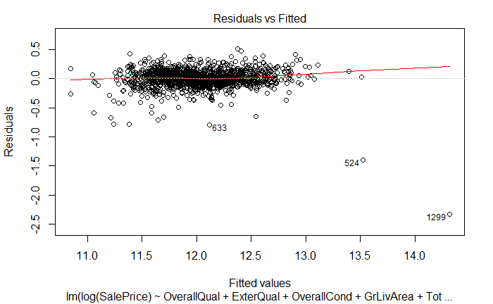

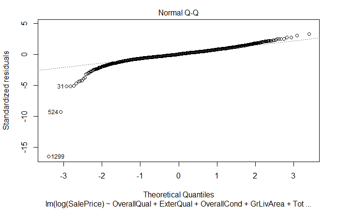

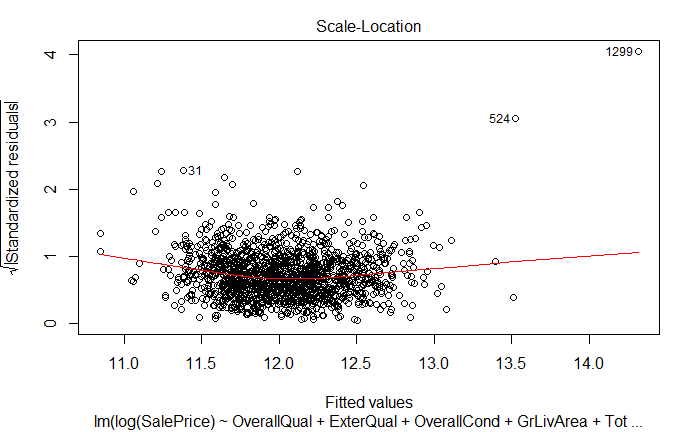

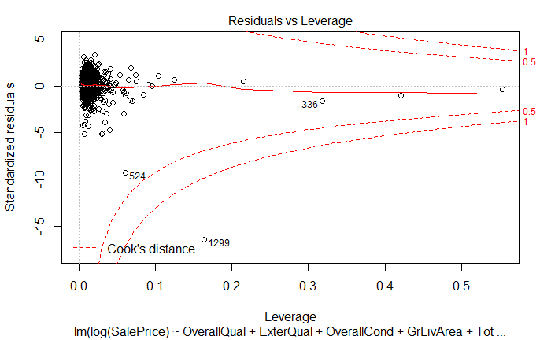

```r
# 49164.74
#Plot of Residual vs Fitted
plot(train_lm)
```

## Step 12 Cross Validation to find expected RMSE of LM method

```r
# Cross Validation to find Expected RMSE & R^2
library(caret)
train(log(SalePrice)~ OverallQual+OverallCond+ExterQual +GrLivArea+TotalBsmtSF+KitchenQual+RoofMatl+GarageArea+YearBuilt+YearRemodAdd+LotArea*Neighborhood+BedroomAbvGr+MSZoning +RoofStyle+HeatingQC+Fireplaces,
      data = train_data ,
      method = "lm",
      trControl = trainControl(method="repeatedcv", repeats = 10, number=10))
```

```
Linear Regression

1460 samples
  17 predictor

No pre-processing
Resampling: Cross-Validated (10 fold, repeated 10 times)
Summary of sample sizes: 1314, 1314, 1313, 1315, 1316, 1313, ...
Resampling results:

  RMSE       Rsquared  MAE
  0.1569735  0.847025  0.1033798

Tuning parameter 'intercept' was held constant at a value of TRUE
```

```r
print(paste0("Expected out of sample RMSE of Train Data", 0.1569735))
```

```
[1] "Expected out of sample RMSE of Train Data0.1569735"
```

```r
print(paste0("Expected R^2 of Train ", 0.847025))
```

```
[1] "Expected R^2 of Train 0.847025"
```

### Step 13: We cross checked LM analysis by comparing it with corelation.

### For that we found most colrealted numeric predictor which are having corelation > 0.5

```r
# We used cor method to find predictors which are having corelation with Sale Price >0.5
for (col in colnames(train_data)){
    if(is.numeric(train_data[,col])){
        if( abs(cor(train_data[,col],train_data$SalePrice)) > 0.5){
            print(col)
            print( cor(train_data[,col],train_data$SalePrice) )
        }
    }
}
```

```
[1] "OverallQual"
[1] 0.7909816
[1] "YearBuilt"
[1] 0.5228973
[1] "YearRemodAdd"
[1] 0.507101
[1] "ExterQual"
[1] -0.6368837
[1] "BsmtQual"
[1] -0.6208861
[1] "TotalBsmtSF"
[1] 0.6135806
[1] "X1stFlrSF"
[1] 0.6058522
[1] "GrLivArea"
```

[output cut: 17 more lines]

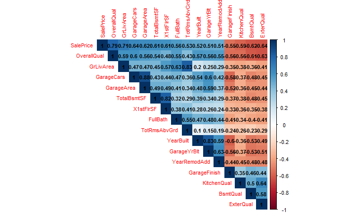

```r
corr.df <- train_data
correlations <- cor(corr.df)
corr.SalePrice <- as.matrix(sort(correlations[,'SalePrice'], decreasing = TRUE))
corr.idx <- names(which(apply(corr.SalePrice, 1, function(x) (x > 0.5 | x < -0.5))))
install.packages("corrplot")
library(corrplot)
corrplot(as.matrix(correlations[corr.idx,corr.idx]), type = 'upper', method='color', addCoef.col = 'black', tl.cex = .7,cl.cex = .7, number.cex=.7)
```

### Step 14 : Ridge Model

### We ran Ridge model with 10 folde cross validation and identified best lambda values for which we received smallest out of sample RMSE and high Accuracy

### Step 15 Ridge model with best lambda

### Step 16 : Lasso Model

### Step 17 : Lasso Model with best lambda

### We ran Lasso model with 10 folde cross validation and identified best lambda values for which we received smallest out of sample RMSE and high Accuracy

### Step 18 : Mix model

### We ran Mix model with 10 folde cross validation and identified best lambda and alpha values for which we received smallest out of sample RMSE and high Accuracy

We ran Mix model with 10 folde cross validation and identified best lambda values for which we received smallest out of sample RMSE and high Accuracy

```r
# Using Ridge model with 10 fold cross validation
ridge_mod <- train(log(SalePrice) ~ .,
                   data = train_data,
                   preProcess = c("center", "scale"),
                   method = "glmnet",
                   trControl = trainControl(method="repeatedcv", repeats = 10, number=10),
                   tuneGrid= expand.grid(
                     alpha=0,
                     lambda = seq(0,300, 1)))
```

[output not shown]

```r
ridge_mod
```

```
glmnet

1460 samples
  76 predictor

Pre-processing: centered (76), scaled (76)
Resampling: Cross-Validated (10 fold, repeated 10 times)
Summary of sample sizes: 1315, 1314, 1314, 1314, 1314, 1313, ...
Resampling results across tuning parameters:

  lambda  RMSE       Rsquared   MAE
    0     0.1479060  0.8634907  0.09558916
    1     0.1712262  0.8542824  0.11563371
    2     0.1985786  0.8479443  0.13946548
    3     0.2216248  0.8444811  0.15938399
```

[output cut: 251 more lines]

```r
#alpha = 0 and lambda = 0.
#lambda  RMSE      Rsquared   MAE
#  0.00    42399.23  0.7483286  19084.64
ridge1 <- ridge_mod$finalModel$tuneValue
# Using lasso model 10 fold cross validation
lasso_mod <- train(log(SalePrice) ~ .,
                   data = train_data,
                   preProcess = c("center", "scale"),
                   method = "glmnet",
                  trControl = trainControl(method="repeatedcv", repeats = 10, number=10),
                   tuneGrid= expand.grid(
                     alpha=1,
                     lambda = seq(0,5, .01)))
```

[output not shown]

```r
lasso_mod
```

```
glmnet

1460 samples
  76 predictor

Pre-processing: centered (76), scaled (76)
Resampling: Cross-Validated (10 fold, repeated 10 times)
Summary of sample sizes: 1316, 1312, 1315, 1313, 1315, 1315, ...
Resampling results across tuning parameters:

  lambda  RMSE       Rsquared   MAE
  0.00    0.1503564  0.8587492  0.09679266
  0.01    0.1496236  0.8613230  0.09779298
  0.02    0.1580610  0.8499934  0.10491256
  0.03    0.1682596  0.8349462  0.11363941
  0.04    0.1755217  0.8262875  0.12016776
  0.05    0.1825537  0.8187930  0.12643062
  0.06    0.1898006  0.8112644  0.13289728
  0.07    0.1971888  0.8040266  0.13959865
  0.08    0.2047166  0.7968915  0.14652840
  0.09    0.2127267  0.7884865  0.15388381
  0.10    0.2209281  0.7794098  0.16130842
  0.11    0.2291392  0.7702561  0.16867599
  0.12    0.2369839  0.7628518  0.17551926
  0.13    0.2446500  0.7569024  0.18204419
  0.14    0.2523310  0.7518385  0.18854974
  0.15    0.2603523  0.7453043  0.19534322
  0.16    0.2686902  0.7367101  0.20235714
  0.17    0.2772994  0.7255354  0.20951332
  0.18    0.2859028  0.7127553  0.21662724
  0.19    0.2944413  0.6987810  0.22367373
  0.20    0.3026523  0.6861991  0.23041741
  0.21    0.3104220  0.6766298  0.23681485
  0.22    0.3177538  0.6720010  0.24285476
  0.23    0.3249790  0.6693240  0.24881769
  0.24    0.3321274  0.6692396  0.25470643
  0.25    0.3394173  0.6691513  0.26071963
  0.26    0.3468331  0.6691449  0.26687356
  0.27    0.3543750  0.6691449  0.27312172
  0.28    0.3620355  0.6691449  0.27947595
```

[output cut: 211 more lines]

```
  2.40    0.3987111        NaN  0.30981985
  2.41    0.3987111        NaN  0.30981985
  2.42    0.3987111        NaN  0.30981985
  2.43    0.3987111        NaN  0.30981985
  2.44    0.3987111        NaN  0.30981985
  2.45    0.3987111        NaN  0.30981985
  2.46    0.3987111        NaN  0.30981985
  2.47    0.3987111        NaN  0.30981985
  2.48    0.3987111        NaN  0.30981985
  2.49    0.3987111        NaN  0.30981985
 [ reached getOption("max.print") -- omitted 251 rows ]

Tuning parameter 'alpha' was held constant at a value of 1
RMSE was used to select the optimal model using  the smallest value.
The final values used for the model were alpha = 1 and lambda = 0.01.
```

```r
# alpha = 1 and lambda = 0.01.
# 0.01    0.1465071  0.8667940  0.09419690
######Using 10 fold cross validation with Mix Glmnet model
mix_mod <- train(log(SalePrice) ~ .,
data = train_data,
preProcess = c("center", "scale"),
 trControl = trainControl(method="repeatedcv", repeats = 10, number=10),
method = "glmnet")
```

[output not shown]

```r
mix_mod
```

```
glmnet

1460 samples
  76 predictor

Pre-processing: centered (76), scaled (76)
Resampling: Cross-Validated (10 fold, repeated 10 times)
Summary of sample sizes: 1314, 1315, 1314, 1314, 1312, 1314, ...
Resampling results across tuning parameters:

  alpha  lambda        RMSE       Rsquared   MAE
  0.10   0.0006526281  0.1494842  0.8608683  0.09654348
  0.10   0.0065262807  0.1486045  0.8623083  0.09605182
  0.10   0.0652628067  0.1477146  0.8665674  0.09663003
  0.55   0.0006526281  0.1493379  0.8611076  0.09646082
  0.55   0.0065262807  0.1469959  0.8653066  0.09566130
  0.55   0.0652628067  0.1728371  0.8346609  0.11775431
  1.00   0.0006526281  0.1490076  0.8616336  0.09629888
  1.00   0.0065262807  0.1472505  0.8654542  0.09624325
  1.00   0.0652628067  0.1935059  0.8086323  0.13636112

RMSE was used to select the optimal model using  the smallest value.
The final values used for the model were alpha = 0.55 and lambda = 0.006526281.
```

```r
#alpha = 0.55 and lambda = 0.006526281.
# 0.55   0.0065262807  0.1425968  0.8719324  0.08984347
mix_mod$finalModel$tuneValue
```

|  | alpha | lambda |
| --- | --- | --- |
| 5 | 0.55 | 0.006526281 |

```r
coef(mix_mod$finalModel, mix_mod$finalModel$tuneValue$lambda)
```

```
77 x 1 sparse Matrix of class "dgCMatrix"
                          1
(Intercept)    1.202405e+01
Id            -3.564665e-05
MSSubClass    -1.342298e-02
MSZoning      -8.343433e-03
LotFrontage    .
LotArea        1.570385e-02
Street         7.152947e-03
LotShape      -7.803776e-03
LandContour    2.210332e-03
Utilities     -3.919158e-04
LotConfig      .
LandSlope      5.110308e-03
Neighborhood   7.466602e-04
Condition1     .
Condition2    -6.420343e-03
BldgType      -8.906898e-03
HouseStyle     .
OverallQual    1.022092e-01
OverallCond    3.857614e-02
YearBuilt      4.155732e-02
YearRemodAdd   1.494255e-02
RoofStyle      8.967237e-04
RoofMatl       2.572914e-03
Exterior1st    .
Exterior2nd    .
MasVnrType     .
MasVnrArea     .
ExterQual     -8.971018e-04
ExterCond      4.401085e-03
Foundation     7.346181e-03
BsmtQual      -1.636244e-02
BsmtCond       4.041279e-04
BsmtExposure  -7.311307e-03
BsmtFinType1  -1.573479e-02
BsmtFinSF1     2.099616e-03
BsmtFinType2   .
BsmtFinSF2     7.847744e-04
BsmtUnfSF      .
```

[output cut: 24 more lines]

```
GarageArea     1.366906e-03
GarageQual     .
GarageCond     3.551754e-04
PavedDrive     1.064981e-02
WoodDeckSF     1.051705e-02
OpenPorchSF    .
EnclosedPorch  1.828037e-03
X3SsnPorch     1.529148e-03
ScreenPorch    1.556901e-02
PoolArea      -8.296169e-03
MiscVal        .
MoSold         .
YrSold        -4.369075e-03
SaleType       .
SaleCondition  2.103749e-02
```

```r
#Using the best lambda value received from 10 fold cross validation
ridge_mod <- train(log(SalePrice) ~ .,
                   data = train_data,
                   preProcess = c("center", "scale"),
                   method = "glmnet",
                   tuneGrid= expand.grid(
                     alpha=0,
                     lambda = 0))
```

[output not shown]

```r
ridge_mod
```

```
glmnet

1460 samples
  76 predictor

Pre-processing: centered (76), scaled (76)
Resampling: Bootstrapped (25 reps)
Summary of sample sizes: 1460, 1460, 1460, 1460, 1460, 1460, ...
Resampling results:

  RMSE       Rsquared   MAE
  0.1531919  0.8535065  0.09767572

Tuning parameter 'alpha' was held constant at a value of 0
Tuning parameter 'lambda'
 was held constant at a value of 0
```

```r
# Out of Sample RMSE for Ridge = 0.1632529
lasso_mod <- train(log(SalePrice) ~ .,
                   data = train_data,
                   preProcess = c("center", "scale"),
                   method = "glmnet",
                   tuneGrid= expand.grid(
                     alpha=1,
                     lambda = 0.01))
```

[output not shown]

```r
lasso_mod
```

```
glmnet

1460 samples
  76 predictor

Pre-processing: centered (76), scaled (76)
Resampling: Bootstrapped (25 reps)
Summary of sample sizes: 1460, 1460, 1460, 1460, 1460, 1460, ...
Resampling results:

  RMSE      Rsquared   MAE
  0.156027  0.8473599  0.09730895

Tuning parameter 'alpha' was held constant at a value of 1
Tuning parameter 'lambda'
 was held constant at a value of 0.01
```

```r
# Out of Sample RMSE for Lasso = 0.1509728
######Mix model
mix_mod <- train(log(SalePrice) ~ .,
data = train_data,
preProcess = c("center", "scale"),
method = "glmnet")
```

[output not shown]

```r
mix_mod
```

```
glmnet

1460 samples
  76 predictor

Pre-processing: centered (76), scaled (76)
Resampling: Bootstrapped (25 reps)
Summary of sample sizes: 1460, 1460, 1460, 1460, 1460, 1460, ...
Resampling results across tuning parameters:

  alpha  lambda        RMSE       Rsquared   MAE
  0.10   0.0006526281  0.1593948  0.8418569  0.09932450
  0.10   0.0065262807  0.1579734  0.8442724  0.09829486
  0.10   0.0652628067  0.1552024  0.8505148  0.09769224
  0.55   0.0006526281  0.1590969  0.8424152  0.09901851
  0.55   0.0065262807  0.1558252  0.8480711  0.09675861
  0.55   0.0652628067  0.1762743  0.8217682  0.11766631
  1.00   0.0006526281  0.1585760  0.8433059  0.09856052
  1.00   0.0065262807  0.1557455  0.8483387  0.09706925
  1.00   0.0652628067  0.1951128  0.7980653  0.13604202

RMSE was used to select the optimal model using  the smallest value.
The final values used for the model were alpha = 0.1 and lambda = 0.06526281.
```

```r
# Out of Sample RMSE for Mix model = 0.1504904
### Creating the prediction on test data
test_predicted_mix <- exp(predict(mix_mod,newdata = test_data))
head(test_predicted_mix)
```

```
       1        2        3        4        5        6
120155.3 149565.6 173669.4 198500.3 188038.4 175781.3
```

```r
myvars <- c("Id")
Submission_mix <- test_data[myvars]
Submission_mix$Saleprice <- test_predicted_mix
write.csv(Submission_mix, "TestdataSalePrice_mix.csv")
# Rank 1830
```

### Step 20 : Random Forest

```r
set.seed(1234)
#rainforest.model <- train(log(SalePrice) ~  GrLivArea +  GarageCars +
#    OverallQual+ KitchenQual + BsmtQual + OverallCond + X1stFlrSF + X2ndFlrSF +
#    PoolArea + ExterQual +  LotArea + TotRmsAbvGrd +
#    MSSubClass + YearBuilt,
#      method="rf",
#      preProcess=c("center","scale"),
#      data= train_data)
#rainforest.model
## Out of sample RMSE for Rain forest
```

### Step 21 : Using KNN Model

```r
set.seed(1234)
model.knn <- train(log(SalePrice) ~ .,
      method="knn",
      preProcess=c("center","scale"),
      data= train_data)
```

[output not shown]

```r
(model.knn)
```

```
k-Nearest Neighbors

1460 samples
  76 predictor

Pre-processing: centered (76), scaled (76)
Resampling: Bootstrapped (25 reps)
Summary of sample sizes: 1460, 1460, 1460, 1460, 1460, 1460, ...
Resampling results across tuning parameters:

  k  RMSE       Rsquared   MAE
  5  0.2005788  0.7459676  0.1388221
  7  0.1938710  0.7656362  0.1344311
  9  0.1900787  0.7779559  0.1322419

RMSE was used to select the optimal model using  the smallest value.
The final value used for the model was k = 9.
```

```r
## Out of sample RMSE for KNN
##0.190087
```

### Impact of the most significant factor OverallQual on Sale Price

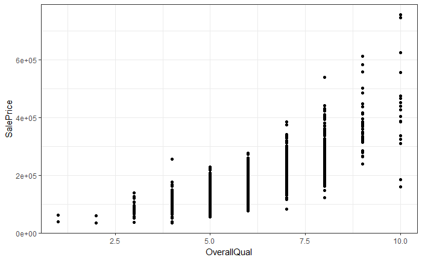

```r
# Overall Quality is the most significant factor in predicting sale price
train_data %>%
  ggplot(aes(OverallQual,SalePrice)) +
  geom_point()+
  theme_bw()
```

### Identifying which neighbourhood are having expensive Homes

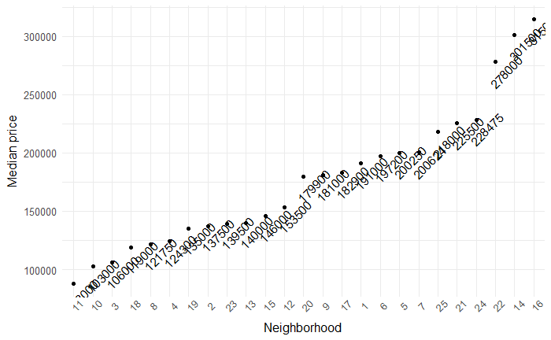

```r
# Identifying which neighbourhood are having expensive Homes
train_data %>%
  group_by(Neighborhood) %>%
  summarise(median.price = median(SalePrice, na.rm = TRUE)) %>%
  arrange(median.price) %>%
  mutate(nhbr.sorted = factor(Neighborhood, levels=Neighborhood)) %>%
  ggplot(aes(x=nhbr.sorted, y=median.price)) +
  geom_point() +
  geom_text(aes(label = median.price, angle = 45), vjust = 2) +
  theme_minimal() +
  labs(x='Neighborhood', y='Median price') +
  theme(text = element_text(size=12),
        axis.text.x = element_text(angle=45))
```

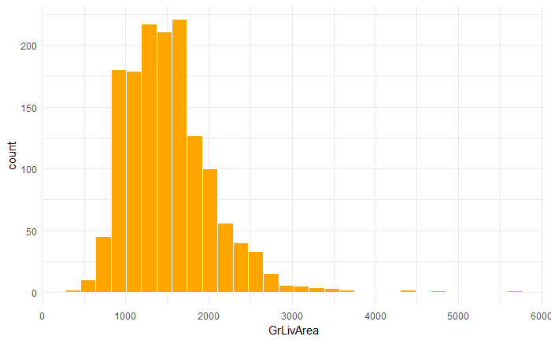

```r
## Identifying GrLivingArea Impact on Housing Price
ggplot(train_data, aes(x=GrLivArea)) +
  geom_histogram(fill='orange',color='white') +
  theme_minimal()
```

### Kitchen Quality also matters in Sale Price

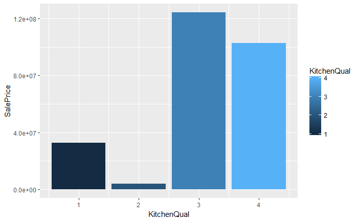

```r
ggplot(data=train_data, aes(x=KitchenQual, y=SalePrice, fill=KitchenQual)) + geom_bar(stat="identity")
```

```r
NA
```

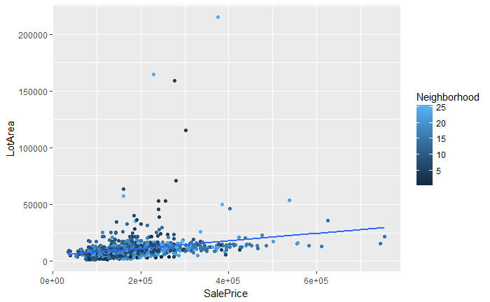

```r
ggplot(train_data, aes(SalePrice, LotArea, col = Neighborhood)) +
  geom_point() +
  stat_smooth(method = "lm", se = F)
```

### Kaggle score : 0.13575

### Kaggle Rank :1822